# Part II - Loan Data from Prosper Insights

## Visualization 5

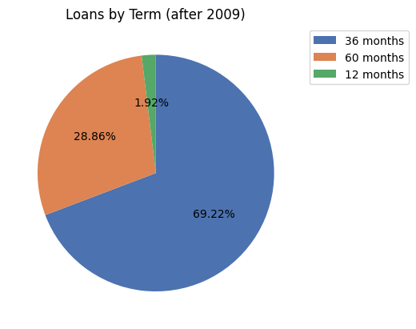

## Visualization 6

Half the borrowers are home owners.

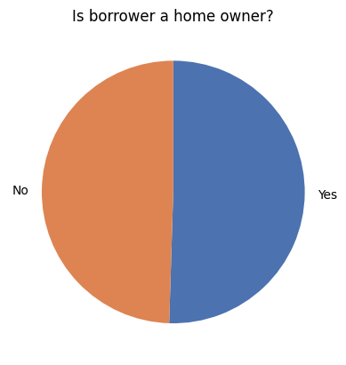

## Visualization 7

If we analyze the loan amount distribution, we'll notice several spikes at "round" values. Without these values, the loan amount has a right-skewed distribution.

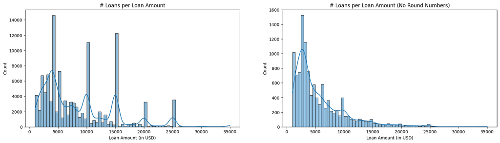

## Visualization 8

`BorrowerAPR` and `BorrowerRate` are highly correlated, but there's another variable (most likely categorical) that's grouping the loans after 2009.

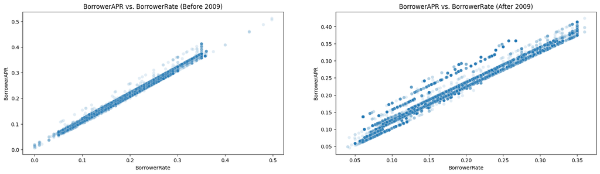

## Visualization 9

Higher credit grades (for both variables) lead to lower borrower rates.

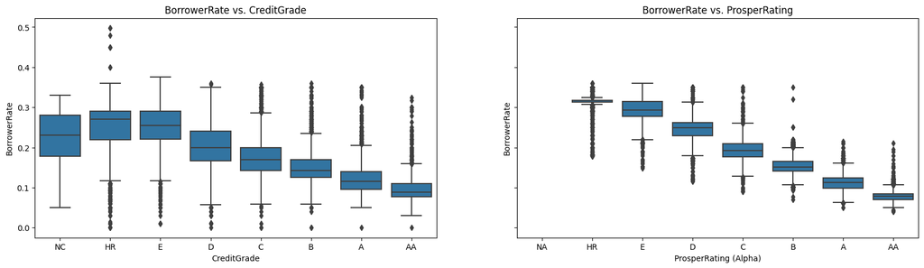

## Visualization 10

At least for deals after 2009, the term is a factor that increases the APR over the rate.

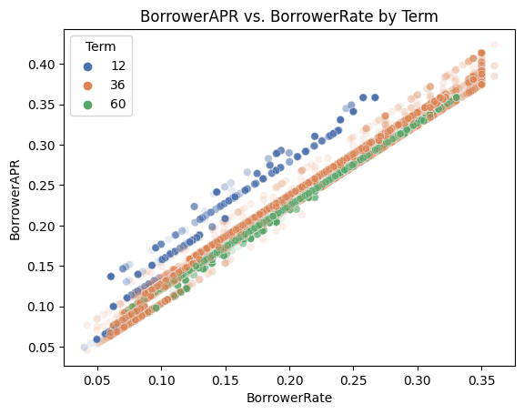